# Location Prediction From Music

```r
library('stats')
library('MASS')
library(glmnet)
```

```r
data <- read.csv("Geographical Original of Music/default_plus_chromatic_features_1059_tracks.txt", header = FALSE, sep = ",")
colnames(data)[117:118] <- c("lat", "long")
ynames<- c("lat", "long")
x<- data[, !(colnames(data) %in% ynames)]
y<- data[, (colnames(data) %in% ynames)]
xMatrix <- as.matrix(x)
yMatrix <- as.matrix(y)
transformedY <- y
y.lat <- transformedY$lat + 90.01
y.long <- transformedY$long + 180.01
```

##### 1.1 First, build a straightforward linear regression of latitude (resp. longitude) against features. What is the R-squared? Plot a graph evaluating each regression.

```r
#y.lat is latitude
model1 <- lm(y.lat~xMatrix)
print(paste("R - Square for latitude regression: ", summary(model1)$r.squared))
```

```
[1] "R - Square for latitude regression:  0.292809200483579"
```

```r
print(paste("MSE for latitude regression: ", mean(summary(model1)$residuals^2)))
```

```
[1] "MSE for latitude regression:  240.748148858785"
```

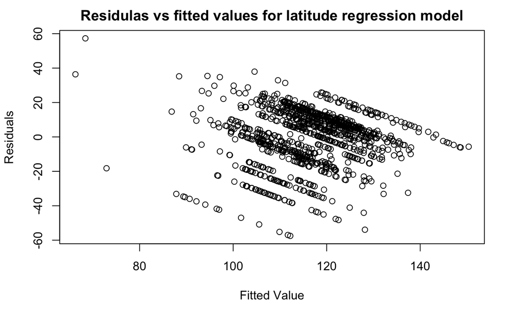

```r
plot(fitted(model1),resid(model1), main ="Residulas vs fitted values for latitude regression model", xlab="Fitted Value", ylab="Residuals" )
```

```r
#y.long is longitude
model2 <- lm(y.long~xMatrix)
print(paste("R - Square for longitude regression: ", summary(model2)$r.squared))
```

```
[1] "R - Square for longitude regression:  0.364576702965342"
```

```r
print(paste("MSE for longitude regression: ", mean(summary(model2)$residuals^2)))
```

```
[1] "MSE for longitude regression:  1613.81929356418"
```

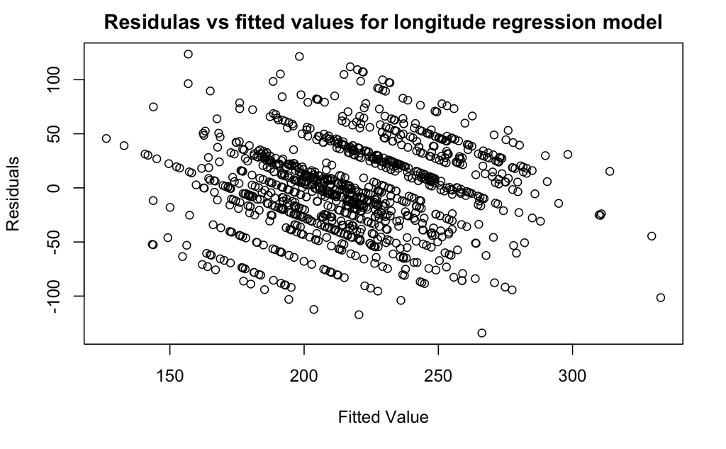

```r
plot(fitted(model2),resid(model2), main ="Residulas vs fitted values for longitude regression model", xlab="Fitted Value", ylab="Residuals" )
```

1.2 Does a Box-Cox transformation improve the regressions? Notice that the dependent variable has some negative values, which Box-Cox doesn’t like. You can deal with this by remembering that these are angles, so you get to choose the origin. why do you say so? For the rest of the exercise, use the transformation if it does improve things, otherwise, use the raw data.

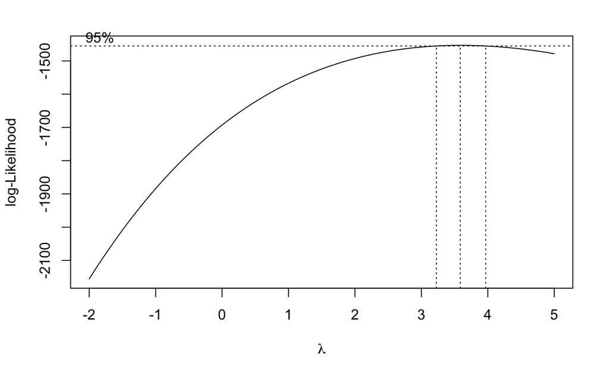

```r
#linear transform the data inorder to avoid negative values in box cox transformation
boxY.lat <- boxcox(y.lat~xMatrix, lambda = seq(-2, 5, 1/10), plotit = TRUE)
```

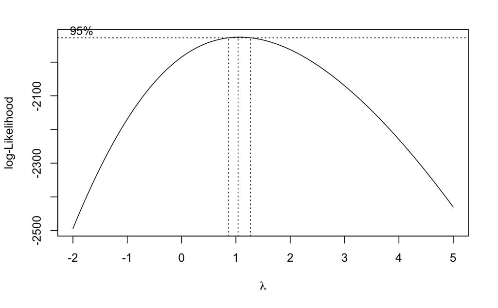

```r
#title("Plot for Boxcox transformation of lattitude")
boxY.long <- boxcox(y.long~xMatrix, lambda = seq(-2, 5, 1/10), plotit = TRUE)
```

```r
#title("Plot for Boxcox transformation of longitude")
#store lambda,
lambda.lat <- boxY.lat$x[which.max(boxY.lat$y)]
lambda.long <- boxY.long$x[which.max(boxY.long$y)]
#transform dependent variables
BoxCoxTransformed.lat <- ((y.lat ^lambda.lat) - 1) / lambda.lat
BoxCoxTransformed.long <- ((y.long ^lambda.long) - 1) / lambda.long
#latitude box cox model
BoxCoxLat.lm <- lm(BoxCoxTransformed.lat~xMatrix)
print(paste("R - Square for latitude regression (Box Cox Tranformed): ", summary(BoxCoxLat.lm)$r.squared))
```

```
[1] "R - Square for latitude regression (Box Cox Tranformed):  0.327071289226048"
```

```r
print(paste("MSE for latitude regression (Box Cox Tranformed): ", mean(summary(BoxCoxLat.lm)$residuals^2)))
```

```
[1] "MSE for latitude regression (Box Cox Tranformed):  8803820487822.89"
```

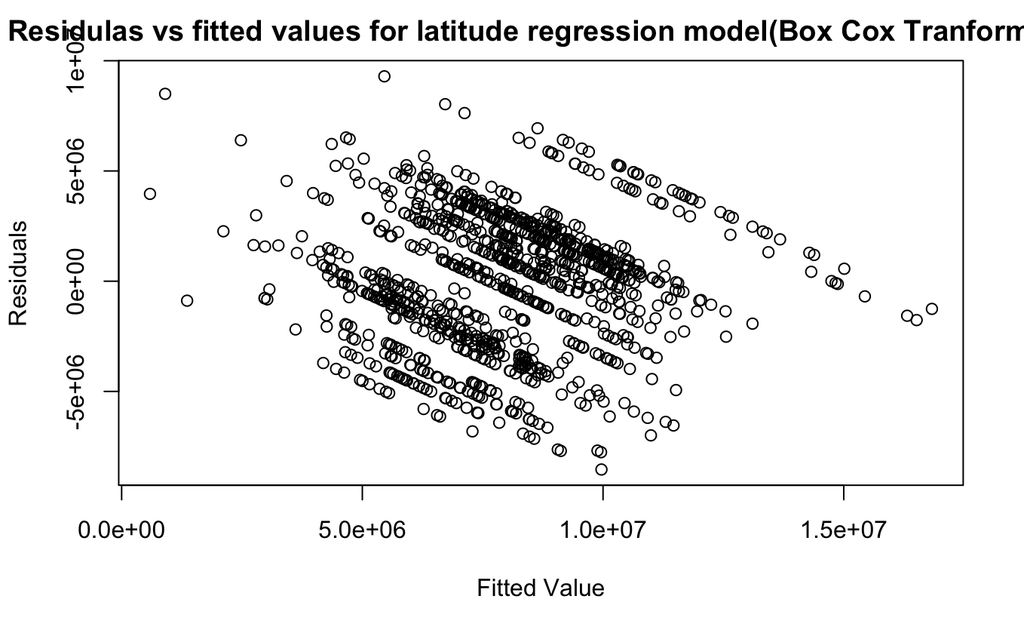

```r
plot(fitted(BoxCoxLat.lm),resid(BoxCoxLat.lm), main ="Residulas vs fitted values for latitude regression model(Box Cox Tranformed)", xlab="Fitted Value", ylab="Residuals" )
```

```r
#logitude box cox model
BoxCoxLong.lm <- lm(BoxCoxTransformed.long~xMatrix)
print(paste("R - Square for Longitude regression (Box Cox Tranformed): ", summary(BoxCoxLong.lm)$r.squared))
```

```
[1] "R - Square for Longitude regression (Box Cox Tranformed):  0.364861988194393"
```

```r
print(paste("MSE for Longitude regression (Box Cox Tranformed): ", mean(summary(BoxCoxLong.lm)$residuals^2)))
```

```
[1] "MSE for Longitude regression (Box Cox Tranformed):  2487.30173508599"
```

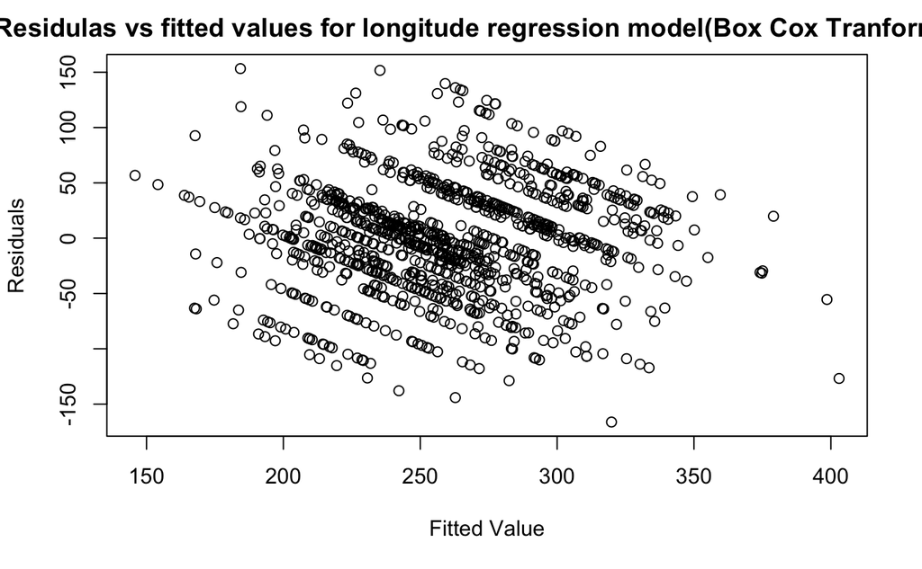

```r
plot(fitted(BoxCoxLong.lm),resid(BoxCoxLong.lm), main ="Residulas vs fitted values for longitude regression model(Box Cox Tranformed)", xlab="Fitted Value", ylab="Residuals" )
```

1.3 Use glmnet to produce: 1.3.1 A regression regularized by L2 (equivalently, a ridge regression). You should estimate the regularization coefficient that produces the minimum error. Is the regularized regression better than the unregularized regression?

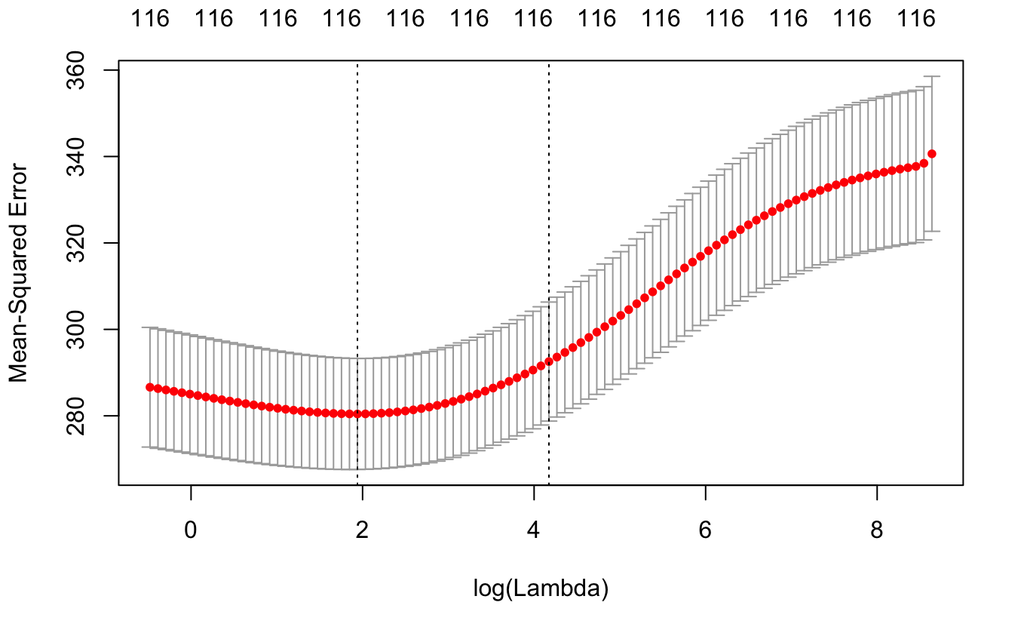

```r
#unregularized
#Regularized
latitudeRidge.lm = cv.glmnet(x=xMatrix, y=y.lat,alpha=0,nfold = 10, family= "gaussian")
plot(latitudeRidge.lm)
```

```r
#R^2
print(cat("The minimum mean square error is: ", min(latitudeRidge.lm$cvm)))
```

```
The minimum mean square error is:  280.4288NULL
```

```r
print(cat("We get mininimum mean square error by using lambda of: ", latitudeRidge.lm$lambda.min))
```

```
We get mininimum mean square error by using lambda of:  6.95961NULL
```

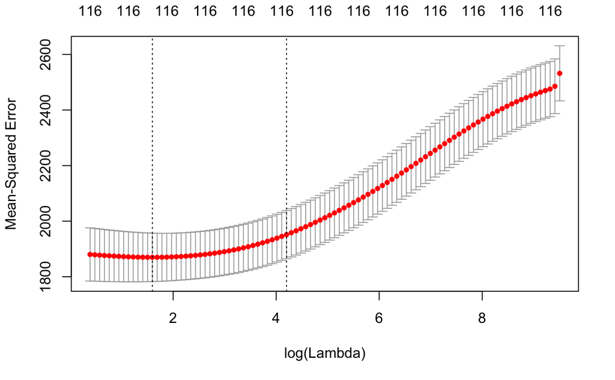

```r
longitudeRidge.lm = cv.glmnet(x=xMatrix, y=y.long,alpha=0,nfold = 10, family= "gaussian")
plot(longitudeRidge.lm)
```

```r
#R^2
longitudeRidge.lm.pred <- predict(longitudeRidge.lm, s = longitudeRidge.lm$lambda.min, newx = xMatrix)
print(cat("The minimum mean square error is: ", min(latitudeRidge.lm$cvm)))
```

```
The minimum mean square error is:  280.4288NULL
```

```r
print(cat("We get mininimum mean square error by using lambda of: ", latitudeRidge.lm$lambda.min))
```

```
We get mininimum mean square error by using lambda of:  6.95961NULL
```

1.3.2 A regression regularized by L1 (equivalently, a lasso regression). You should estimate the regularization coefficient that produces the minimum error. How many variables are used by this regression? Is the regularized regression better than the unregularized regression?

```r
#Regularized
latitudeLasso.lm = cv.glmnet(x=xMatrix, y=y.lat,alpha=1,nfold = 10, family= "gaussian")
plot(latitudeLasso.lm)
#R^2
print(cat("The minimum mean square error is: ", min(latitudeLasso.lm$cvm)))
print(cat("We get mininimum mean square error by using lambda of: ", latitudeLasso.lm$lambda.min))
print(paste("The number of variables used in latitude lasso regression: " , latitudeLasso.lm$nzero[which.min(latitudeLasso.lm$cvm)] - 1))

longitudeLasso.lm = cv.glmnet(x=xMatrix, y=y.long,alpha=1,nfold = 10, family= "gaussian")
plot(longitudeLasso.lm)
#R^2
print(cat("The minimum mean square error is: ", min(latitudeRidge.lm$cvm)))
print(cat("We get mininimum mean square error by using lambda of: ", latitudeRidge.lm$lambda.min))
print(paste("The number of variables used in longitude lasso regression: " , longitudeLasso.lm$nzero[which.min(longitudeLasso.lm$cvm)] - 1))
```

[output not shown]

1.3.3 A regression regularized by elastic net (equivalently, a regression regularized by a convex combination of L1 and L2). Try three values of alpha, the weight setting how big L1 and L2 are. You should estimate the regularization coefficient that produces the minimum error. How many variables are used by this regression? Is the regularized regression better than the unregularized regression?

```r
#Latitude
alpha <-c(0.25,0.5,0.75)
for(a in alpha){
  latitudecv.lm = cv.glmnet(x=xMatrix, y=BoxCoxTransformed.lat,alpha=a ,nfold = 10, family="gaussian")
  plot(latitudecv.lm)
  title(paste("Latitude Elastic Net with Alpha of ",a))
  print(cat("The minimum mean square error is: ", min(latitudecv.lm$cvm)))
  print(cat("We get mininimum mean square error by using lambda of: ", latitudecv.lm$lambda.min))
  print(paste("The number of variables used in longitude lasso regression: " , latitudecv.lm$nzero[which.min(latitudecv.lm$cvm)] - 1))

}


for(a in alpha){
  longitudecv.lm = cv.glmnet(x=xMatrix, y=BoxCoxTransformed.long,alpha=a ,nfold = 10, family="gaussian")
  plot(longitudecv.lm)
  title(paste("Longitude Elastic Net with Alpha of ",a))
  print(cat("The minimum mean square error is: ", min(longitudecv.lm$cvm)))
  print(cat("We get mininimum mean square error by using lambda of: ", longitudecv.lm$lambda.min))
  print(paste("The number of variables used in longitude lasso regression: " , longitudecv.lm$nzero[which.min(longitudecv.lm$cvm)] - 1))

}
```

[output not shown]

# Problem 2

https://piazza.com/class/jchzguhsowz6n9?cid=985